# Group7_Assignment3

7/22/2017

#### Group 7 is:

- Shameka Brayton
- Paola Igarteburu
- Akash Nautiyal
- Brad O’Hara
- Tim Raiswell

## Pre-Modeling Tasks

#### Setting Up Libraries

Below is the set of R packages and options that we used in our analysis.

```r
library(DMwR)
library(caret)
library(e1071)
library(performanceEstimation)
library(psych)
library(corrplot)
library(randomForest)
library(dummies)
library(tidyverse)
library(ordinal)
options(scipen=999) # Presents raw numbers in regression results, not scientific notation.
```

#### Setting working directory and loading ‘Red Wine’ file

```r
#Working directory
setwd("../Group7Assignment3")
#Load file which is already in R format
load('redWine.Rdata')
```

#### Exploratory Analysis

We begin by examining the variables available in the dataset and their basic statistics.

##### Class of each variable

```r
sapply(redWine, class)
```

```
##        fixed.acidity     volatile.acidity          citric.acid
##            "numeric"            "numeric"            "numeric"
##       residual.sugar            chlorides  free.sulfur.dioxide
##            "numeric"            "numeric"            "numeric"
## total.sulfur.dioxide              density                   pH
##            "numeric"            "numeric"            "numeric"
##            sulphates              alcohol              quality
##            "numeric"            "numeric"            "integer"
```

All variables are numeric; the dependent variable “quality” is an integer. We check the distribution of the data for outliers and normality ahead of a regression exercise.

##### Distribution of each variable

```r
rw <- describe(redWine, IQR = TRUE)
rw
```

```
##                      vars    n  mean    sd median trimmed   mad  min
## fixed.acidity           1 1599  8.32  1.74   7.90    8.15  1.48 4.60
## volatile.acidity        2 1599  0.53  0.18   0.52    0.52  0.18 0.12
## citric.acid             3 1599  0.27  0.19   0.26    0.26  0.25 0.00
## residual.sugar          4 1599  2.54  1.41   2.20    2.26  0.44 0.90
## chlorides               5 1599  0.09  0.05   0.08    0.08  0.01 0.01
## free.sulfur.dioxide     6 1599 15.87 10.46  14.00   14.58 10.38 1.00
## total.sulfur.dioxide    7 1599 46.47 32.90  38.00   41.84 26.69 6.00
## density                 8 1599  1.00  0.00   1.00    1.00  0.00 0.99
## pH                      9 1599  3.31  0.15   3.31    3.31  0.15 2.74
## sulphates              10 1599  0.66  0.17   0.62    0.64  0.12 0.33
## alcohol                11 1599 10.42  1.07  10.20   10.31  1.04 8.40
## quality                12 1599  5.64  0.81   6.00    5.59  1.48 3.00
##                         max  range skew kurtosis   se   IQR
## fixed.acidity         15.90  11.30 0.98     1.12 0.04  2.10
## volatile.acidity       1.58   1.46 0.67     1.21 0.00  0.25
## citric.acid            1.00   1.00 0.32    -0.79 0.00  0.33
## residual.sugar        15.50  14.60 4.53    28.49 0.04  0.70
## chlorides              0.61   0.60 5.67    41.53 0.00  0.02
## free.sulfur.dioxide   72.00  71.00 1.25     2.01 0.26 14.00
## total.sulfur.dioxide 289.00 283.00 1.51     3.79 0.82 40.00
## density                1.00   0.01 0.07     0.92 0.00  0.00
## pH                     4.01   1.27 0.19     0.80 0.00  0.19
## sulphates              2.00   1.67 2.42    11.66 0.00  0.18
## alcohol               14.90   6.50 0.86     0.19 0.03  1.60
## quality                8.00   5.00 0.22     0.29 0.02  1.00
```

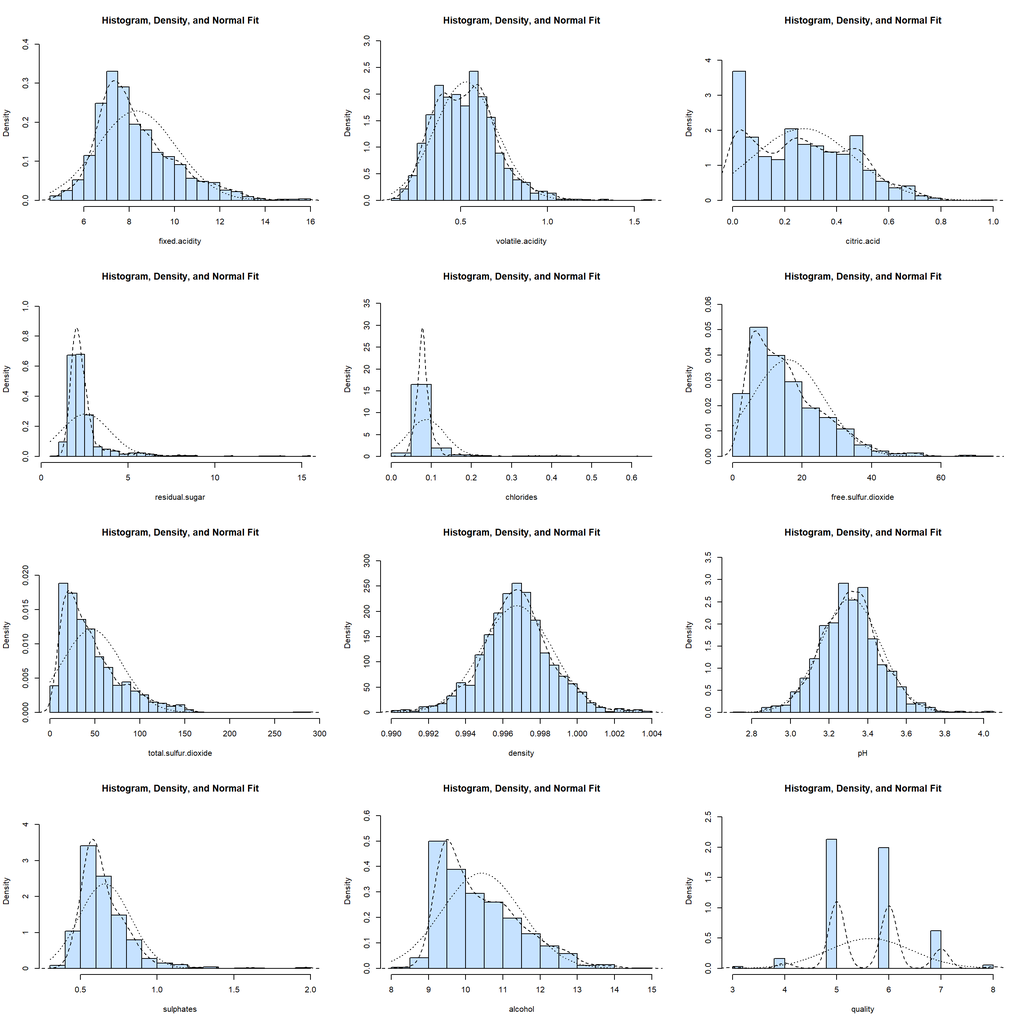

```r
multi.hist(redWine, bcol = "slategray1")
```

#### Distribution of ‘Quality’ Variable

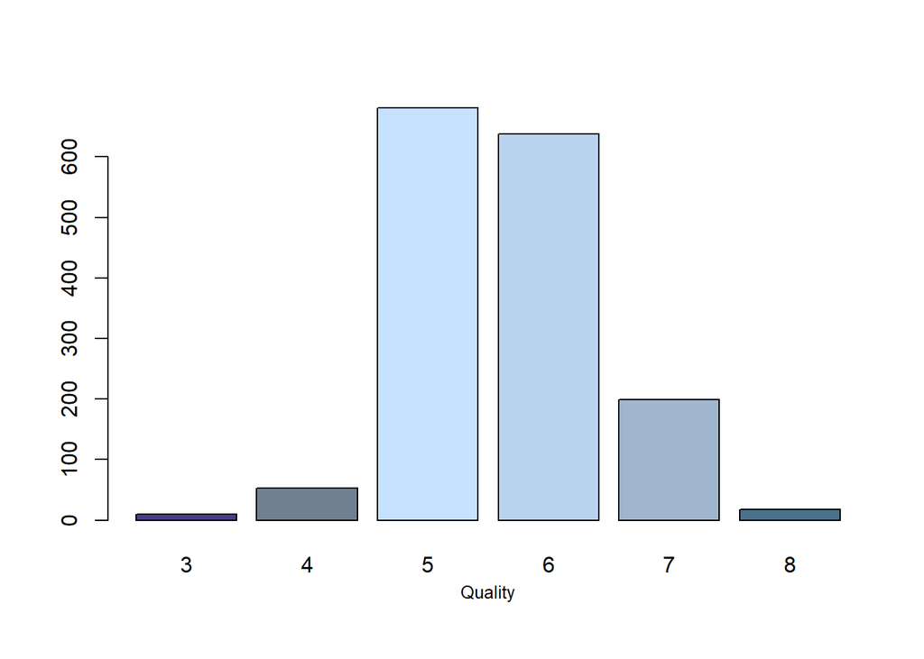

```r
attach(redWine)
barplot((table(round(quality, 1))), col=c("slateblue4", "slategray", "slategray1", "slategray2", "slategray3", "skyblue4"))
mtext("Quality", side=1, outer=F, line=2, cex=0.8)
```

Based on the bar plot, we can see that quality of wine has a high frequency of ‘5’ and ‘6’ scores. Class prediction of heads (high scoring wines), and tails (low-scoring wines) will be made more difficult by this distribution. It may be more suitable to group the wines into low, medium and high quality (or similar) clusters.

#### Log transformation of the variables

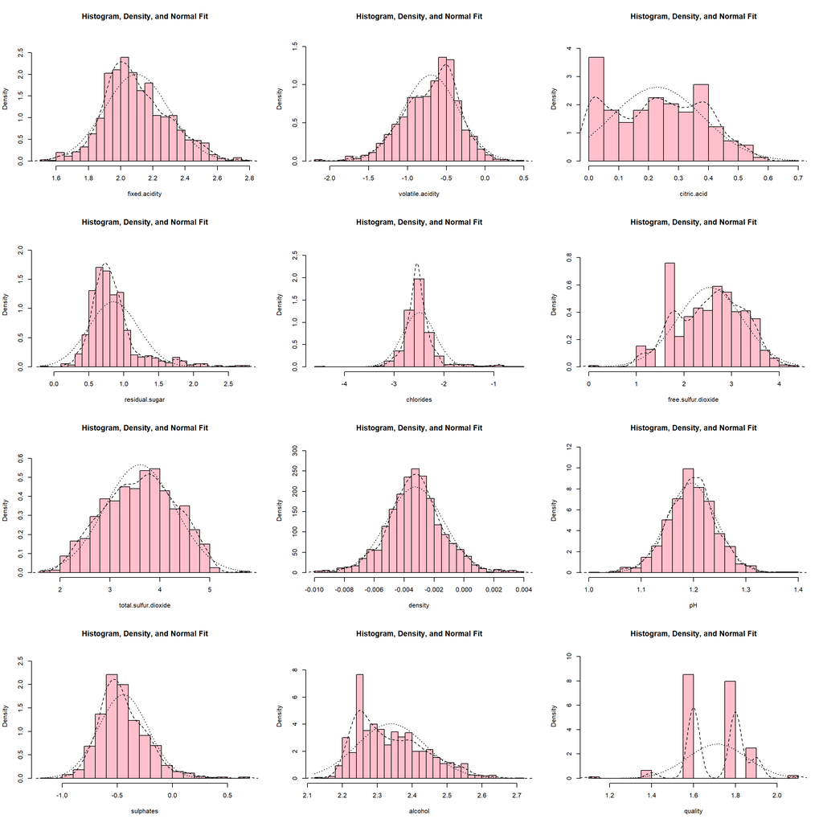

```r
logcit <- redWine$citric.acid + 1 # we add one to this variable to prevent '-inf' errors when logging zeros.
logred <- redWine
logred$citric.acid <- logcit
logred <- log(logred)
logred$quality <- as.numeric(logred$quality)
logred$quality <- round(logred$quality, 1)
multi.hist(logred, bcol="pink")
```

The transformation significantly improves the variable distribution, and so we will work with the log data for the exercise. Logging the ‘quality’ variable is suitable during its treatment as a continuous variable (yielding elasticity in the interpretation of results); later, when we treat ‘quality’ scores as classes, we do not use a log transformed format.

#### Test for variable correlation

We test for linear relationships.

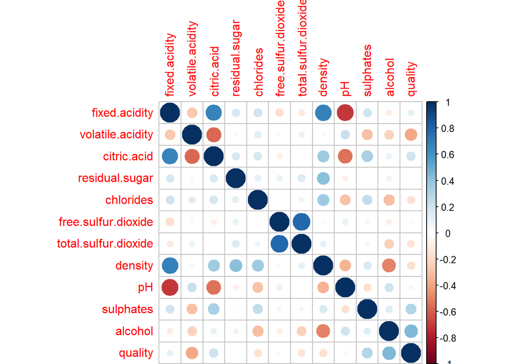

```r
l <- cor(logred)
corrplot(l, method = "circle")
```

There appear to be several strong linear relationships between ‘quality’ and the other variables, especially ‘alocohol’(+ve), ‘sulphates’(+ve) and ‘volatile.acidity’(-ve).

##### Spearman Rank Correlation of Variables (in case of non-normal distributions)

```r
round(cor(logred[, -12], method = "spearman"), 2)
```

```
##                      fixed.acidity volatile.acidity citric.acid
## fixed.acidity                 1.00            -0.28        0.66
## volatile.acidity             -0.28             1.00       -0.61
## citric.acid                   0.66            -0.61        1.00
## residual.sugar                0.22             0.03        0.18
## chlorides                     0.25             0.16        0.11
## free.sulfur.dioxide          -0.18             0.02       -0.08
## total.sulfur.dioxide         -0.09             0.09        0.01
## density                       0.62             0.03        0.35
## pH                           -0.71             0.23       -0.55
## sulphates                     0.21            -0.33        0.33
## alcohol                      -0.07            -0.22        0.10
##                      residual.sugar chlorides free.sulfur.dioxide
## fixed.acidity                  0.22      0.25               -0.18
## volatile.acidity               0.03      0.16                0.02
## citric.acid                    0.18      0.11               -0.08
## residual.sugar                 1.00      0.21                0.07
## chlorides                      0.21      1.00                0.00
## free.sulfur.dioxide            0.07      0.00                1.00
## total.sulfur.dioxide           0.15      0.13                0.79
## density                        0.42      0.41               -0.04
## pH                            -0.09     -0.23                0.12
## sulphates                      0.04      0.02                0.05
## alcohol                        0.12     -0.28               -0.08
##                      total.sulfur.dioxide density    pH sulphates alcohol
## fixed.acidity                       -0.09    0.62 -0.71      0.21   -0.07
## volatile.acidity                     0.09    0.03  0.23     -0.33   -0.22
## citric.acid                          0.01    0.35 -0.55      0.33    0.10
## residual.sugar                       0.15    0.42 -0.09      0.04    0.12
## chlorides                            0.13    0.41 -0.23      0.02   -0.28
## free.sulfur.dioxide                  0.79   -0.04  0.12      0.05   -0.08
## total.sulfur.dioxide                 1.00    0.13 -0.01      0.00   -0.26
## density                              0.13    1.00 -0.31      0.16   -0.46
## pH                                  -0.01   -0.31  1.00     -0.08    0.18
## sulphates                            0.00    0.16 -0.08      1.00    0.21
## alcohol                             -0.26   -0.46  0.18      0.21    1.00
```

We also used a Spearman correlation test, as it uses ranks as opposed to actual values of variables to measure correlation. This makes it less sensitive to bias due to effect of outliers. It also does not require the assumption of normality.

## Data Preparation

#### Train and Test Set Creation for Standard and Log Versions

We randomly split the data set in two sub-sets (70%-30%). We will use the larger sub-set to train the model and the smaller sub-set to test the models. We analzed both standard and log-transformed versions of the data.

```r
Sample <- sample(1:nrow(redWine), size=0.7*nrow(redWine))
red_tr <- redWine[Sample,]
red_ts <- redWine[-Sample,]
```

```r
logSample <- sample(1:nrow(logred), size=0.7*nrow(logred))
logred_tr <- logred[logSample,]
logred_ts <- logred[-logSample,]
```

## Modeling Tasks

### Support Vector Machine

#### Default Support Vector Machine (SVM) Treatment

We ran the SVM with default parameters. In this case it will default to eps-regression. Here we decided to round the results to kake the output more intuitive.

#### SVM using standard data

```r
set.seed(1234)
svm_default <- svm(quality ~., red_tr)
#Get predictions with rounding to the closest integer.
ps1 <- round(predict(svm_default, red_ts),0) #add predictions as separate column in test frame

#Results
regr.eval(red_ts$quality, ps1)
```

```
##        mae        mse       rmse       mape
## 0.42291667 0.48958333 0.69970232 0.07814732
```

This approach results in fairly high error rates. The table below is an artificial (rounded) view of the predictions, but gives some sense of where the model is failing: in the mid-range quality wines, where there is muddiness between scores ‘5’ and ‘6’. ####Table of results

```r
(cm<- table(ps1, red_ts$quality))
```

```
##
## ps1   3   4   5   6   7   8
##   5   3   9 156  62   2   0
##   6   0   5  56 114  33   2
##   7   0   1   1  13  22   1
```

#### SVM for log-transformed data

```r
set.seed(1234)
logsvm_default <- svm(quality ~., logred_tr)
#Get predictions with rounding to the closest integer.
logps1 <- round(predict(logsvm_default, logred_ts),1) #add predictions as separate column in test frame

#Results
regr.eval(logred_ts$quality, logps1)
```

```
##        mae        mse       rmse       mape
## 0.07166667 0.01187500 0.10897247 0.04269207
```

#### Table of results

```r
(cm<- table(logps1, logred_ts$quality))
```

```
##
## logps1 1.1 1.4 1.6 1.8 1.9 2.1
##    1.5   0   1   2   0   0   0
##    1.6   1  12 114  22   0   0
##    1.7   0   4  60  66   4   0
##    1.8   0   2  22  84  29   4
##    1.9   0   0   1  18  30   4
```

We would need to be careful how we interpreted this analysis for a third-party, as it looks as if we are examining a classification problem. We aren’t but we get a rough sense of how the model is performing visualizing results in this way.

#### Tuning SVM Parameters to Balance the Variance/Bias Tradeoff

We attempted to further tune the SVM model. We ran the SVM on a radial kernel, but tuned the kernel parameters to balance variance/bias tradeoff.

```r
x <- logred_tr[,-5]
y <- logred_tr[,5]

log_svm_tune <- tune(svm, quality~., data=logred_tr, train.x=x, train.y=y, ranges=list(cost=1:20, gamma=2^(-1:1)))
summary(log_svm_tune)
```

```
##
## Parameter tuning of 'svm':
##
## - sampling method: 10-fold cross validation
##
## - best parameters:
##  cost gamma
##     5   0.5
##
## - best performance: 0.06155786
##
## - Detailed performance results:
##    cost gamma      error dispersion
## 1     1   0.5 0.07629833 0.03070104
## 2     2   0.5 0.06556532 0.02533358
```

[output cut: 58 more lines]

#### Post-tuning SVM log model

```r
svm_tuned <- svm(quality ~., data=logred_tr, cost=10, gamma=0.5)
#Get predictions with rounding to the closest integer.
ps_tune <- round(predict(svm_tuned, logred_ts),1)
#Results
regr.eval(logred_ts$quality, ps_tune)
```

```
##        mae        mse       rmse       mape
## 0.07583333 0.01337500 0.11565034 0.04547474
```

## Random Forest Regression

Staying with our original methodology of using both standard and log-transformed data for the regression experiment, we used the random forest algorithm.

```r
#Set Seed
set.seed(1234)
#SVM model with linear
forest <- randomForest(quality ~., red_tr, ntree=200)
#Get predictions
forest_ps <- round(predict(forest, red_ts),0)
#Results
regr.eval(red_ts$quality, forest_ps)
```

```
##        mae        mse       rmse       mape
## 0.35208333 0.40208333 0.63410041 0.06533482
```

The model improves upon the original SVM model we ran on the raw data but not the SVM model with logged variables. ####Table of results

```r
(cm<- table(forest_ps, red_ts$quality))
```

```
##
## forest_ps   3   4   5   6   7   8
##         5   3  11 163  43   2   0
##         6   0   4  49 138  33   2
##         7   0   0   1   8  22   1
```

#### Random forest with log-transformed data

We now try the same algorithm with log-transformed variables.

```r
#Set Seed
set.seed(1234)
#SVM model with linear
log_forest <- randomForest(quality ~., logred_tr, ntree=200)
#Get predictions
log_forest_ps <- round(predict(log_forest, logred_ts),1)
#Results
regr.eval(logred_ts$quality, log_forest_ps)
```

```
##        mae        mse       rmse       mape
## 0.06729167 0.01060417 0.10297653 0.04021431
```

#### Results

The random forest regession run on the log-transformed data has the lowest error scores yet.

```r
(cm<- table(log_forest_ps, logred_ts$quality))
```

```
##
## log_forest_ps 1.1 1.4 1.6 1.8 1.9 2.1
##           1.5   0   1   3   0   0   0
##           1.6   0  11 104  16   0   0
##           1.7   1   7  81  69   5   0
##           1.8   0   0  11 105  37   3
##           1.9   0   0   0   0  21   5
```

The ensemble model reaches optimal error rates somewhere between 50 and 100 trees.

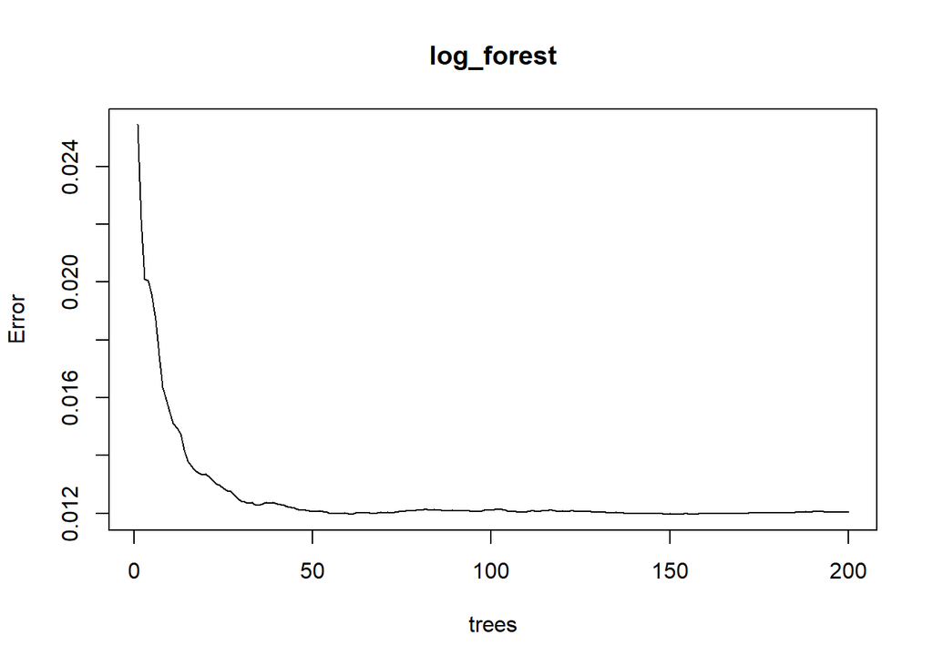

```r
#Plot error rate
plot(log_forest)
```

#### Review relative variable importance

```r
m <- randomForest(quality ~., logred_tr, ntree=200, importance=T)
importance(m)
```

```
##                        %IncMSE IncNodePurity
## fixed.acidity        12.056750      1.300723
## volatile.acidity     20.572706      2.766231
## citric.acid          12.792123      1.403789
## residual.sugar        8.325561      1.253286
## chlorides            10.409968      1.582469
## free.sulfur.dioxide  12.171147      1.130849
## total.sulfur.dioxide 17.429629      1.857548
## density              14.474823      1.631991
## pH                   15.227128      1.366396
## sulphates            23.032658      2.944670
## alcohol              26.277451      3.723429
```

Alcohol level, sulphates content and and volatile acidity are the most useful variables to the random forest algorithm when reducing uncertainty about the quality of the wine.

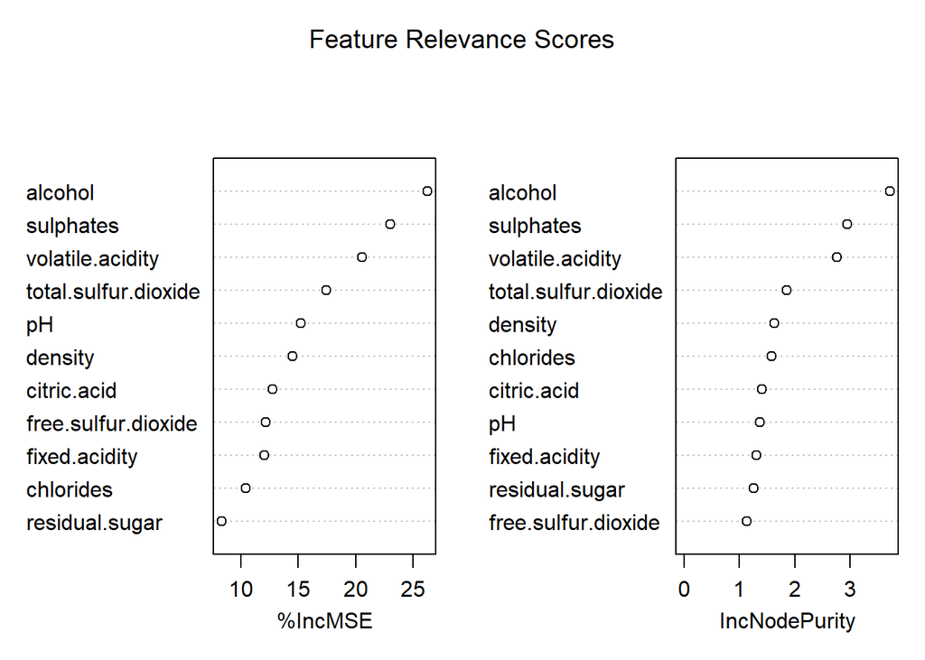

```r
varImpPlot(m, main="Feature Relevance Scores")
```

```r
#%IncMSE is a robust measure. It is the increase in MSE of predictions (estimated with out-of-bag-CV) as a result of variable X being permuted (having its values randomly shuffled).

# IncNodePurity: at each split, we can calculate how much this split *reduces* node impurity (for regression trees, indeed, the difference between RSS before and after the split). This is summed over all splits for that variable, over all trees. i.e. how much information gain we get from the variable.
```

## Treating Red Wine Quality Prediction as a Classification Problem

#### Classification SVM using standard data

This technique results in a model that is only moderately better at differentiating the mid-range quality scores than the SVM regression above. The accuracy and kappa scores show weak to mild predictive ability.

```r
set.seed(1234)
svm_default2 <- svm(quality ~., red_tr)
#Get predictions with rounding to the closest integer.
ps2 <- predict(svm_default2, red_ts) #add predictions as separate column in test frame

#Results
confusionMatrix(red_ts$quality, ps2)
```

```
## Confusion Matrix and Statistics
##
##           Reference
## Prediction   3   4   5   6   7   8
##          3   0   0   2   1   0   0
##          4   0   0  10   4   1   0
##          5   0   0 154  56   3   0
##          6   0   0  59 121   9   0
##          7   0   0   3  39  15   0
##          8   0   0   0   3   0   0
##
## Overall Statistics
##
##                Accuracy : 0.6042
##                  95% CI : (0.5588, 0.6482)
##     No Information Rate : 0.475
##     P-Value [Acc > NIR] : 0.000000009121
##
##                   Kappa : 0.3387
##  Mcnemar's Test P-Value : NA
##
## Statistics by Class:
##
##                      Class: 3 Class: 4 Class: 5 Class: 6 Class: 7 Class: 8
## Sensitivity                NA       NA   0.6754   0.5402  0.53571       NA
## Specificity           0.99375  0.96875   0.7659   0.7344  0.90708  0.99375
## Pos Pred Value             NA       NA   0.7230   0.6402  0.26316       NA
## Neg Pred Value             NA       NA   0.7228   0.6460  0.96927       NA
## Prevalence            0.00000  0.00000   0.4750   0.4667  0.05833  0.00000
## Detection Rate        0.00000  0.00000   0.3208   0.2521  0.03125  0.00000
## Detection Prevalence  0.00625  0.03125   0.4437   0.3937  0.11875  0.00625
## Balanced Accuracy          NA       NA   0.7207   0.6373  0.72140       NA
```

#### SVM standard for log-transformed data

The log-transformed data only perform slightly better than the raw data. The reasons are as follows:

- First, the high frequency of mid-range quality scores makes it hard to tune a model that can distinguish between these and the high- and low-quality wines.
- Second, what little (if any) information we gain from treating wine quality as a class, we lose in distinguishing the classes by degree, i.e. this approach recognizes that 3 $\neq$ 4, but not that 3 $<$ 4. We have, therefore, lost some information.

```r
set.seed(1234)
logsvm_default2 <- svm(quality ~., logred_tr)
#Get predictions with rounding to the closest integer.
logps2 <- predict(logsvm_default2, logred_ts)

#Results
confusionMatrix(logred_ts$quality, logps2)
```

```
## Confusion Matrix and Statistics
##
##           Reference
## Prediction   3   4   5   6   7   8
##          3   0   0   1   0   0   0
##          4   0   0   8  10   0   0
##          5   0   0 157  48   1   0
##          6   0   0  54 118   8   0
##          7   0   0   4  41  21   0
##          8   0   0   0   7   2   0
##
## Overall Statistics
##
##                Accuracy : 0.6167
##                  95% CI : (0.5715, 0.6604)
##     No Information Rate : 0.4667
##     P-Value [Acc > NIR] : 0.00000000002939
##
##                   Kappa : 0.3773
##  Mcnemar's Test P-Value : NA
##
## Statistics by Class:
##
##                      Class: 3 Class: 4 Class: 5 Class: 6 Class: 7 Class: 8
## Sensitivity                NA       NA   0.7009   0.5268  0.65625       NA
## Specificity          0.997917   0.9625   0.8086   0.7578  0.89955  0.98125
## Pos Pred Value             NA       NA   0.7621   0.6556  0.31818       NA
## Neg Pred Value             NA       NA   0.7555   0.6467  0.97343       NA
## Prevalence           0.000000   0.0000   0.4667   0.4667  0.06667  0.00000
## Detection Rate       0.000000   0.0000   0.3271   0.2458  0.04375  0.00000
## Detection Prevalence 0.002083   0.0375   0.4292   0.3750  0.13750  0.01875
## Balanced Accuracy          NA       NA   0.7547   0.6423  0.77790       NA
```

#### Classification with random forest on standard and log-transformed data

The random forest perfoms marginally better on the standard data than its SVM counterpart.However, the random forest run on the log-transformed data is likely the best-performing model thus far with a kappa $>$ 0.5.

```r
forest2 <- randomForest(quality ~., red_tr, ntree=200)
#Get predictions
forest_ps2 <- predict(forest2, red_ts)
#Results
confusionMatrix(red_ts$quality, forest_ps2)
```

```
## Confusion Matrix and Statistics
##
##           Reference
## Prediction   3   4   5   6   7   8
##          3   0   1   2   0   0   0
##          4   0   0   8   6   1   0
##          5   0   0 165  47   1   0
##          6   0   0  51 128   9   1
##          7   0   0   2  27  28   0
##          8   0   0   0   3   0   0
##
## Overall Statistics
##
##                Accuracy : 0.6688
##                  95% CI : (0.6247, 0.7107)
##     No Information Rate : 0.475
##     P-Value [Acc > NIR] : < 0.00000000000000022
##
##                   Kappa : 0.4537
##  Mcnemar's Test P-Value : NA
##
## Statistics by Class:
##
##                      Class: 3 Class: 4 Class: 5 Class: 6 Class: 7 Class: 8
## Sensitivity                NA 0.000000   0.7237   0.6066  0.71795 0.000000
## Specificity           0.99375 0.968685   0.8095   0.7732  0.93424 0.993737
## Pos Pred Value             NA 0.000000   0.7746   0.6772  0.49123 0.000000
## Neg Pred Value             NA 0.997849   0.7640   0.7148  0.97400 0.997904
## Prevalence            0.00000 0.002083   0.4750   0.4396  0.08125 0.002083
## Detection Rate        0.00000 0.000000   0.3438   0.2667  0.05833 0.000000
## Detection Prevalence  0.00625 0.031250   0.4437   0.3937  0.11875 0.006250
## Balanced Accuracy          NA 0.484342   0.7666   0.6899  0.82609 0.496868
```

```r
log_forest2 <- randomForest(quality ~., logred_tr, ntree=200)
#Get predictions
log_forest_ps2 <- predict(log_forest2, logred_ts)
#Results
confusionMatrix(logred_ts$quality, log_forest_ps2)
```

```
## Confusion Matrix and Statistics
##
##           Reference
## Prediction   3   4   5   6   7   8
##          3   0   0   1   0   0   0
##          4   0   0   9   9   0   0
##          5   0   0 161  45   0   0
##          6   0   1  37 132  10   0
##          7   0   0   3  26  37   0
##          8   0   0   0   5   3   1
##
## Overall Statistics
##
##                Accuracy : 0.6896
##                  95% CI : (0.6461, 0.7307)
##     No Information Rate : 0.4521
##     P-Value [Acc > NIR] : < 0.00000000000000022
##
##                   Kappa : 0.5052
##  Mcnemar's Test P-Value : NA
##
## Statistics by Class:
##
##                      Class: 3 Class: 4 Class: 5 Class: 6 Class: 7 Class: 8
## Sensitivity                NA 0.000000   0.7630   0.6083  0.74000 1.000000
## Specificity          0.997917 0.962422   0.8327   0.8175  0.93256 0.983299
## Pos Pred Value             NA 0.000000   0.7816   0.7333  0.56061 0.111111
## Neg Pred Value             NA 0.997835   0.8175   0.7167  0.96860 1.000000
## Prevalence           0.000000 0.002083   0.4396   0.4521  0.10417 0.002083
## Detection Rate       0.000000 0.000000   0.3354   0.2750  0.07708 0.002083
## Detection Prevalence 0.002083 0.037500   0.4292   0.3750  0.13750 0.018750
## Balanced Accuracy          NA 0.481211   0.7979   0.7129  0.83628 0.991649
```

#### Attempting to improve the results by grouping the variables into Low/Med/High quality

Both accuracy and kappa are improved using this technique, though it is obviously a more ‘blunt’ approach to predicting wine quality as we have reduced six classes to three.

```r
log_forest3 <- randomForest(quality ~., logred_tr, ntree=200)
#Get predictions
log_forest_ps3 <- predict(log_forest3, logred_ts)
#Results
confusionMatrix(logred_ts$quality, log_forest_ps3)
```

```
## Confusion Matrix and Statistics
##
##           Reference
## Prediction high low med
##       high   25   5  36
##       low     1 186  38
##       med    11  47 131
##
## Overall Statistics
##
##                Accuracy : 0.7125
##                  95% CI : (0.6697, 0.7526)
##     No Information Rate : 0.4958
##     P-Value [Acc > NIR] : < 0.00000000000000022
##
##                   Kappa : 0.5117
##  Mcnemar's Test P-Value : 0.0007349
##
## Statistics by Class:
##
##                      Class: high Class: low Class: med
## Sensitivity              0.67568     0.7815     0.6390
## Specificity              0.90745     0.8388     0.7891
## Pos Pred Value           0.37879     0.8267     0.6931
## Neg Pred Value           0.97101     0.7961     0.7457
## Prevalence               0.07708     0.4958     0.4271
## Detection Rate           0.05208     0.3875     0.2729
## Detection Prevalence     0.13750     0.4688     0.3937
## Balanced Accuracy        0.79156     0.8102     0.7141
```

The same variables that performed best in the regression models are performing well in the classification treatment.

```r
m <- randomForest(quality ~., logred_tr, ntree=200, importance=T)
importance(m)
```

```
##                           high       low       med MeanDecreaseAccuracy
## fixed.acidity        12.765665 10.355187 10.920444             18.33164
## volatile.acidity     21.821361 17.266824 10.754085             24.40963
## citric.acid          13.840990  9.471017  6.710704             18.28485
## residual.sugar       11.540905  7.906164  9.699226             15.93616
## chlorides             7.931757 13.454115  8.969234             17.73498
## free.sulfur.dioxide  12.022905 11.443599 10.748125             19.34328
## total.sulfur.dioxide 17.264370 16.720015 13.824089             26.64492
## density              15.246375 12.924284 14.058447             22.94337
## pH                    9.627820 10.176791  6.994125             14.23571
## sulphates            26.824806 23.919418 17.225530             33.80797
## alcohol              28.893716 30.023687 17.336410             37.44768
##                      MeanDecreaseGini
## fixed.acidity                51.43503
## volatile.acidity             71.19880
## citric.acid                  50.79583
## residual.sugar               45.09570
## chlorides                    49.40458
## free.sulfur.dioxide          45.32751
## total.sulfur.dioxide         65.02061
## density                      65.42117
## pH                           47.76604
## sulphates                    84.62105
## alcohol                     101.42404
```

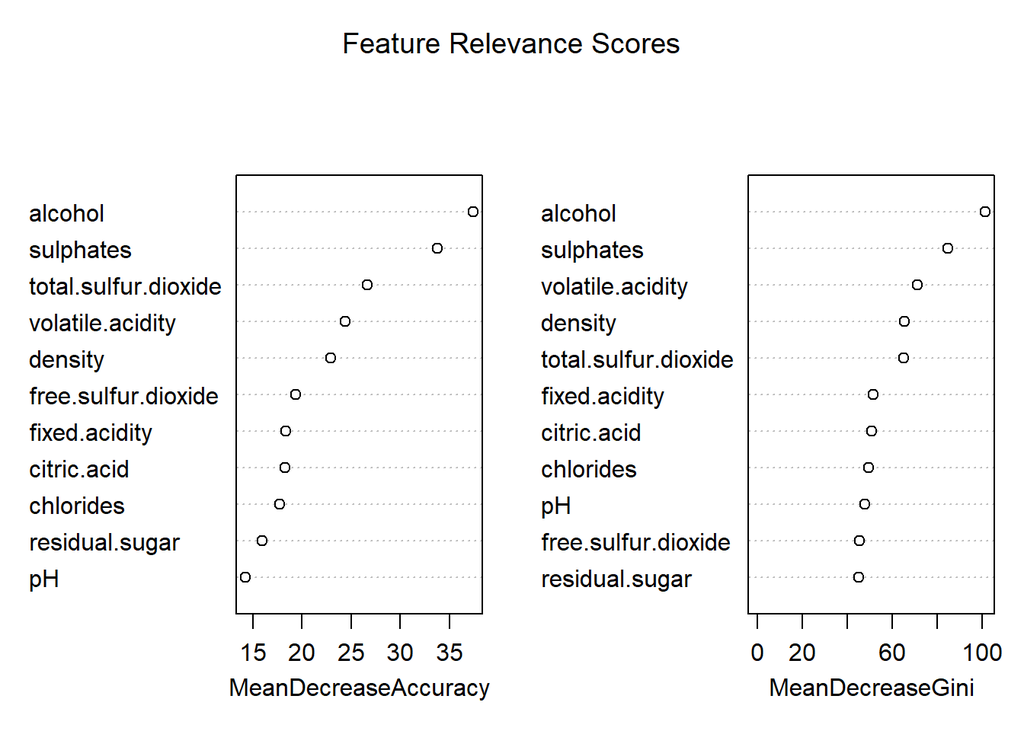

```r
varImpPlot(m, main="Feature Relevance Scores")
```